# Barplots in ggplot2

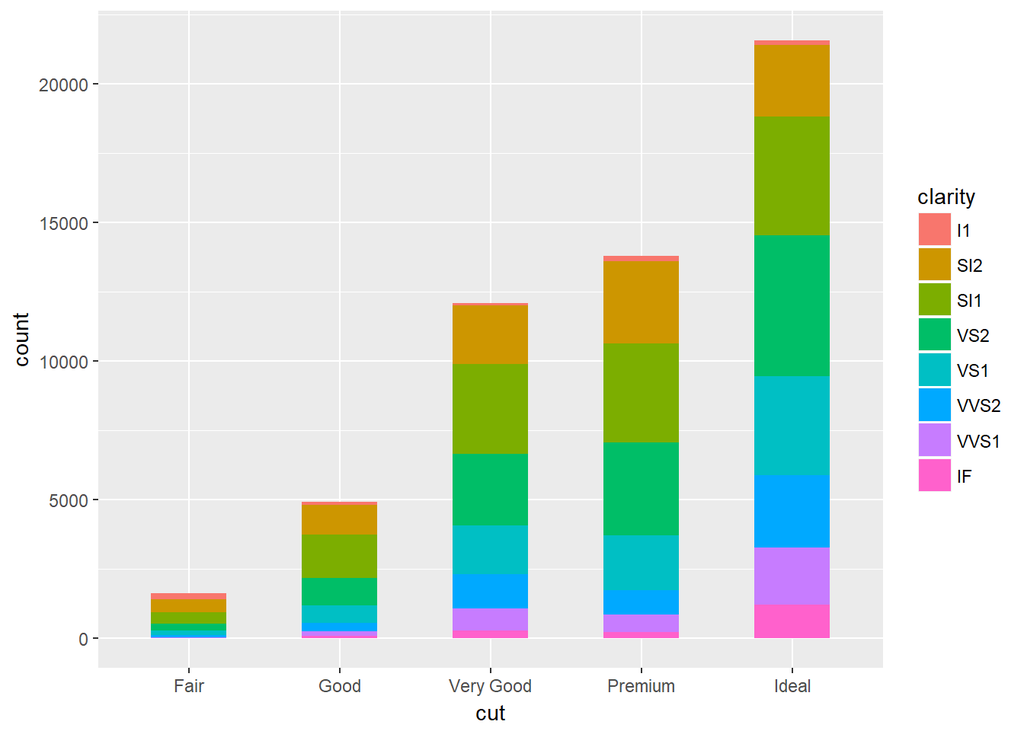

```r
ggplot(diamonds, aes(cut, fill = clarity))+
  geom_bar(width = 0.5)
```

We can create different barplots for each color by using the function facet_wrap

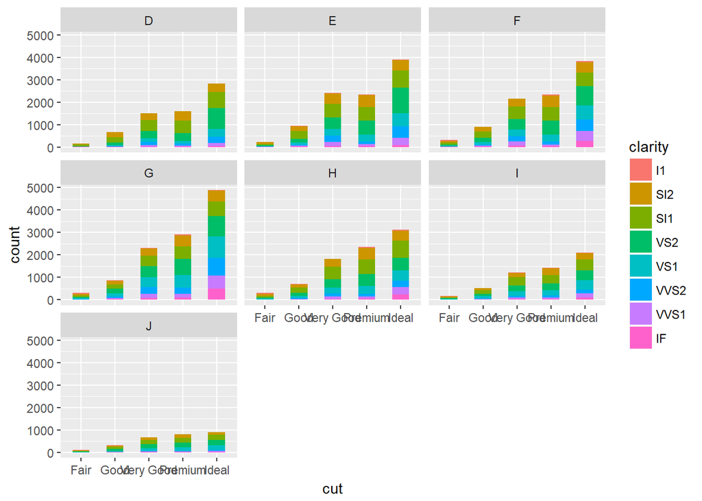

```r
ggplot(diamonds, aes(cut, fill = clarity))+
  geom_bar(width = 0.5)+
  facet_wrap(~ color)
```

This would probably look better if we first tried to minimize the number of windows.There are 5 cuts, 8 levels of clarity and 7 colors let’s try two do a facet wrap by cut instead wrap by cut, make barplots of the clarity levels with the fill by color.

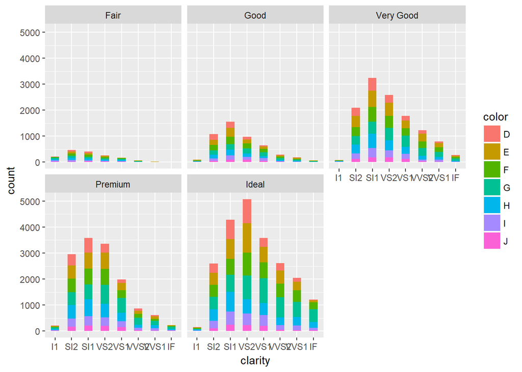

```r
(bar2 <- ggplot(diamonds, aes(clarity, fill = color))+
    geom_bar(width = 0.5)+
    facet_wrap(~ cut))
```

Let’s add axes label, flip the coordinates

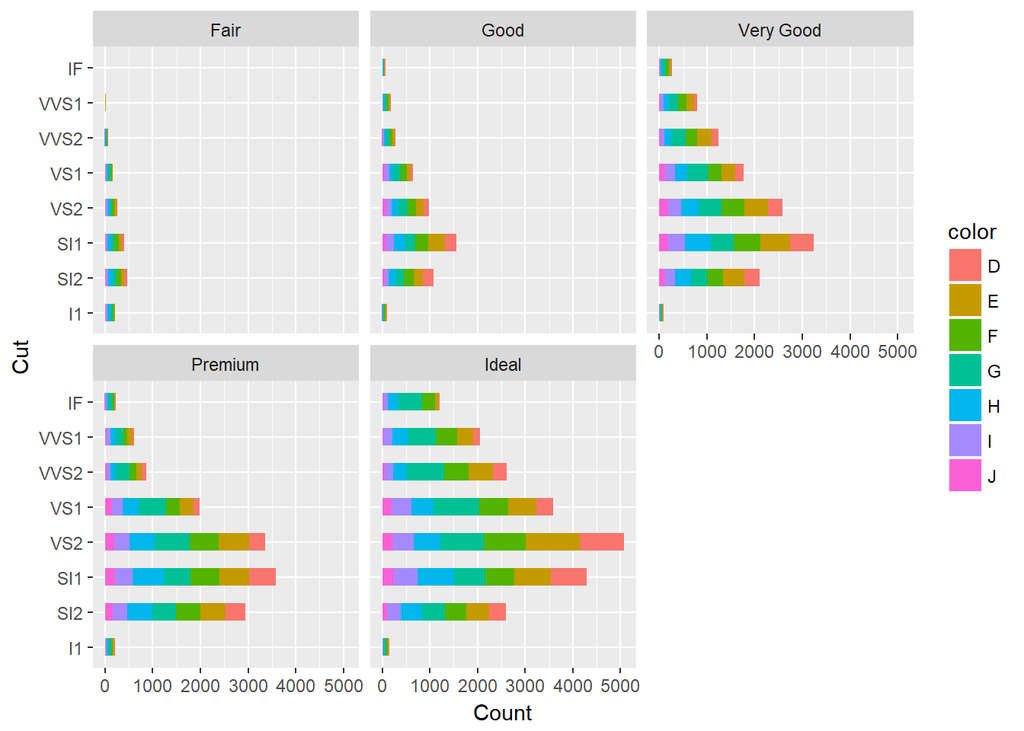

```r
bar2 +
  labs(x = 'Cut', y = 'Count')+
  coord_flip()
```

You can use the facet grid function to stack all five cuts next to each other.

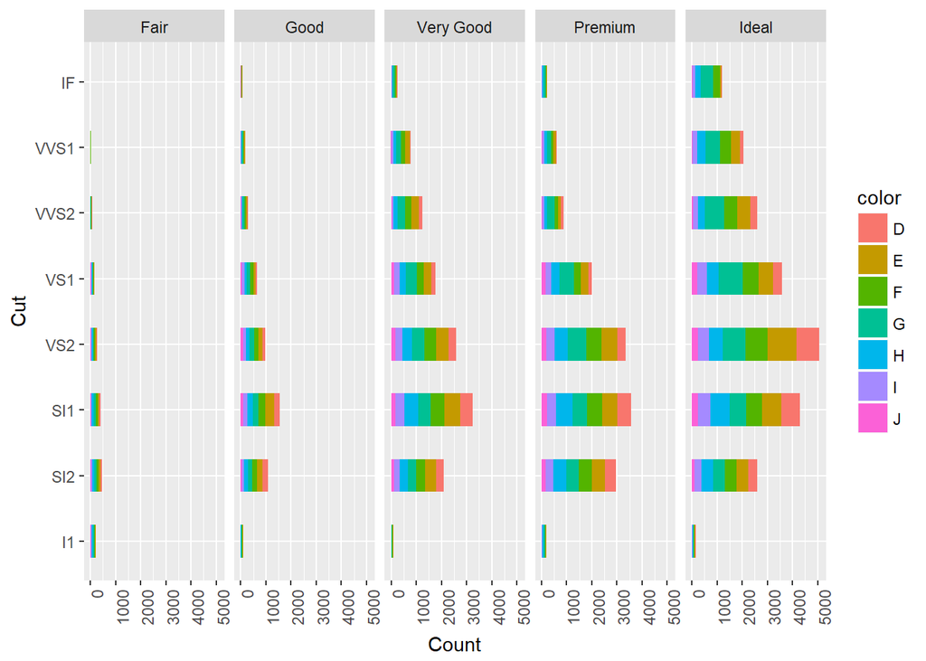

```r
bar2 +
  labs(x = 'Cut', y = 'Count')+
  coord_flip()+
  facet_grid(.~cut)+
  theme(axis.text.x = element_text(angle = 90, hjust = 1, vjust = 1))
```